# Report

## Insights and Visualizations

### Are retweets and favourites related?

To try and answer that question I plotted a scatterplot of Favourite Count against Retweet Count. The plot looks as follows:

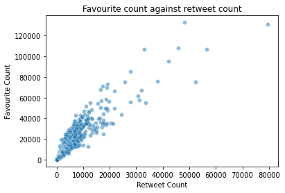

We can see that there is a clear positive correlation between Favourites and Retweets, and that most values are in the range between 0 and 10k retweets, and 0 and 40k favourites, with some very large outliers.

### What are the ten most frequent dog breeds?

To try and answer that question I made a Countplot and plotted only the ten most frequent. I started with the first prediction for each image. The plot looks as follows:

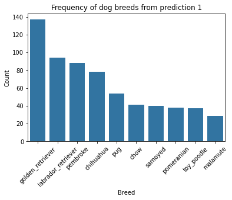

We can see that the ten most frequent dog breeds from prediction 1 are:

- Golden Retriever, Labrador Retriever, Pembroke, Chihuahua, Pug, Chow, Samoyed, Pomeranian, Toy Poodle, Malamute.

The plot for the second prediction for each image looks as follows:

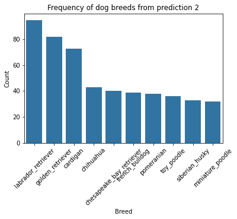

The plot for the third prediction for each image looks as follows:

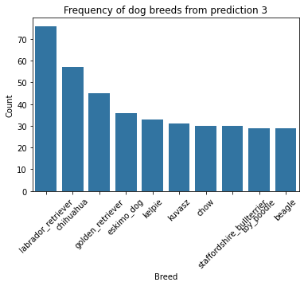

We can see that the ten most frequent dog breeds from prediction 3 are:

- Labrador Retriever, Chihuahua, Golden Retriever, Eskimo Dog, Kelpie, Kuvasz, Chow, Staffordshire Bull Terrier, Beagle, Toy Poodle.

### What are the ten most common dog names?

To try and answer that question I made a Countplot and plotted only the ten most frequent. The plot looks as follows:

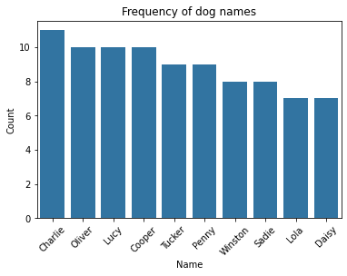

We can see that the most common names are as follows:

- Charlie, Lucy, Cooper, Oliver, Penny, Tucker, Sadle, Winston, Daisy and Lola.

### Overall insights

- Favourites count and Retweets count are positively correlated.
- The most frequent dog breed in p1 is Golden Retriever.
- The most frequent dog breed in p2 is Labrador Retriever.
- The most frequent dog breed in p3 is Labrador Retriever.
- The most common dog name is Charlie (male), followed by Lucy (female).